# Diversity tutorial多样性分析教程

Yong-Xin Liu(刘永鑫), Tao Wen(文涛)

2021-12-10

如果你使用本代码，请引用：

Yong-Xin Liu, Yuan Qin, Tong Chen, Meiping Lu, Xubo Qian, Xiaoxuan Guo & Yang Bai. A practical guide to amplicon and metagenomic analysis of microbiome data. Protein & Cell 2021(12) 5:315-330, doi: https://doi.org/10.1007/s13238-020-00724-8

# 简介 Introduction

## 安装 Installation

The [amplicon R package](https://github.com/microbiota) facilitates statistics and visualization of amplicon profiling data, in particular 16S and ITS alpha / beta diversity, and taxonomy composition.

```r
# 基于CRAN安装R包
p_list = c("ggplot2", "BiocManager", "devtools")
for(p in p_list){if (!requireNamespace(p)){install.packages(p)}
    library(p, character.only = TRUE, quietly = TRUE, warn.conflicts = FALSE)}

# 基于Bioconductor安装R包
if (!requireNamespace("ggtree", quietly = TRUE))
    BiocManager::install("ggtree")

# 基于github安装，检测没有则安装
library(devtools)
if(!requireNamespace("amplicon", quietly = TRUE))
  install_github("microbiota/amplicon")

# 加载R包 Load the package
suppressWarnings(suppressMessages(library(amplicon)))
```

## 实验设计 Design/Metadata

设置基本参数：读取实验设计、设置分组列名、图片宽高

Setting the basic parameter

```r
# Data reading
metadata = read.table("metadata.txt", header=T, row.names=1, sep="\t", comment.char="", stringsAsFactors = F)
head(metadata, n = 3)
```

|  | Group | Date | Site | CRA | CRR | BarcodeSequence | LinkerPrimerSequence | ReversePrimer | Batch | Species | Sequencing | Platform | latitude_longitude | Description |
| --- | --- | --- | --- | --- | --- | --- | --- | --- | --- | --- | --- | --- | --- | --- |
| KO1 | KO | 2017/6/30 | Chaoyang | CRA002352 | CRR117575 | ACGCTCGACA | AACMGGATTAGATACCCKG | ACGTCATCCCCACCTTCC | 1 | Arabidopsis thaliana | Novagene | HiSeq2500 | 39.59 N 116.22 E | Knock-out replicate 1 |
| KO2 | KO | 2017/6/30 | Chaoyang | CRA002352 | CRR117576 | ATCAGACACG | AACMGGATTAGATACCCKG | ACGTCATCCCCACCTTCC | 1 | Arabidopsis thaliana | Novagene | HiSeq2500 | 39.59 N 116.22 E | Knock-out replicate 2 |
| KO3 | KO | 2017/7/2 | Changping | CRA002352 | CRR117577 | ATATCGCGAG | AACMGGATTAGATACCCKG | ACGTCATCCCCACCTTCC | 1 | Arabidopsis thaliana | Novagene | HiSeq2500 | 40.10 N 116.42 E | Knock-out replicate 3 |

```r
# colnames of group ID in metadata
# 设置实验分组列名
group = "Group"
# Output figure width and height
# Letter纸图片尺寸为单栏89 mm，双栏183 mm，页面最宽为247 mm
# 推荐比例16：10，即半版89 mm x 56 mm; 183 mm x 114 mm
width = 89
height = 59

# 手动指定分组列和顺序，默认为字母顺序
# metadata[[group]] = factor(metadata[[group]], levels = c("WT","KO","OE"))
# 按实验设计中分组出现顺序
# metadata[[group]] = factor(metadata[[group]], levels = unique(metadata[[group]]))
```

# α多样性 Alpha diversity

## 箱线图+统计 Boxplot+Statistics

绘制主要分三步： Plotting each figure mainly include three step:

1. 读取数据并预览格式Reading data and viewing format;
2. 参数调整和绘图Paramters adjustment and plotting;
3. 保存图片Saving figure.

```r
# vegan.txt中还有6种常用α多样性，alpha.txt中有11种α多样性
alpha_div = read.table("alpha/vegan.txt", header=T, row.names=1, sep="\t", comment.char="")
head(alpha_div, n = 3)
```

|  | richness | chao1 | ACE | shannon | simpson | invsimpson |
| --- | --- | --- | --- | --- | --- | --- |
| KO1 | 1088 | 1255.921 | 1247.326 | 5.836661 | 0.9897133 | 97.21328 |
| KO2 | 1087 | 1228.984 | 1240.586 | 5.952234 | 0.9932847 | 148.91412 |
| KO3 | 945 | 1173.864 | 1167.303 | 5.522083 | 0.9877762 | 81.80789 |

```r
# capitalize
library(Hmisc)
colnames(alpha_div) = capitalize(colnames(alpha_div))
colnames(alpha_div)
```

```
#> [1] "Richness"   "Chao1"      "ACE"        "Shannon"    "Simpson"
#> [6] "Invsimpson"
```

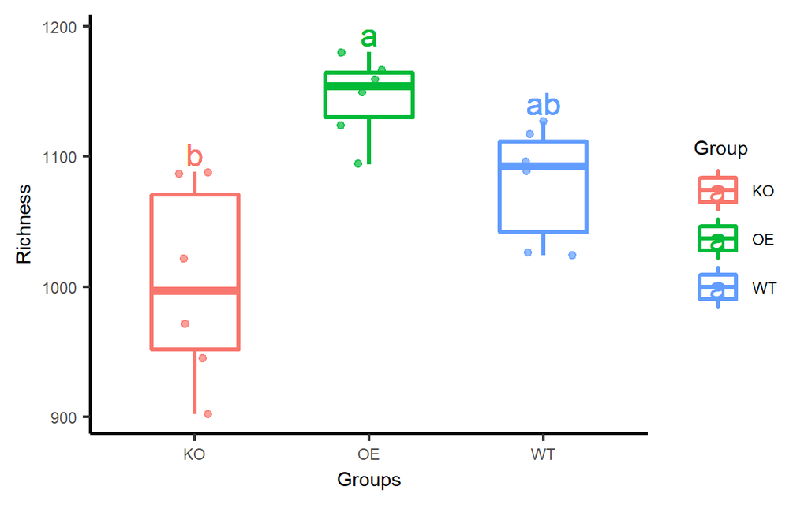

```r
# 选择指数"Richness","Chao1","ACE","Shannon","Simpson","Invsimpson"
alpha_index = "Richness"

# Plotting alpha diversity Richness boxplot and stat
(p = alpha_boxplot(alpha_div, index = alpha_index, metadata, groupID = group))
```

```r
# Saving figure
# 保存图片，大家可以修改图片名称和位置，长宽单位为毫米
ggsave(paste0("alpha/alpha_boxplot_",alpha_index,".pdf"), p, width = width, height = height, units = "mm")
# 另存图片用于后期拼图
p1 = p

# 尝试探索不同的多样性各类
colnames(alpha_div)
```

```
#> [1] "Richness"   "Chao1"      "ACE"        "Shannon"    "Simpson"
#> [6] "Invsimpson"
```

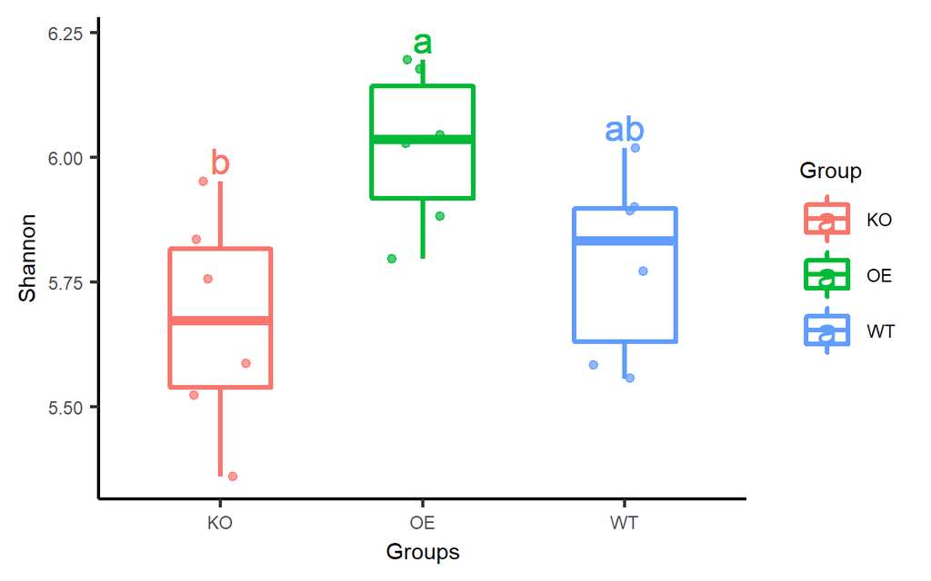

```r
alpha_boxplot(alpha_div, index = "Shannon", metadata, groupID = group)
```

```r
# 尝试不同的分组方式
colnames(metadata)
```

```
#>  [1] "Group"                "Date"                 "Site"
#>  [4] "CRA"                  "CRR"                  "BarcodeSequence"
#>  [7] "LinkerPrimerSequence" "ReversePrimer"        "Batch"
#> [10] "Species"              "Sequencing"           "Platform"
#> [13] "latitude_longitude"   "Description"
```

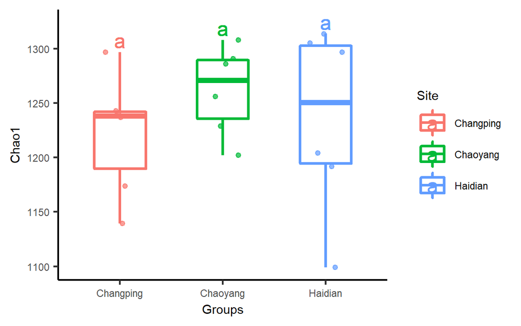

```r
alpha_boxplot(alpha_div, index = "Chao1", metadata, groupID = "Site")
```

## 稀释曲线+标准误 Rarefaction curve and standard error

```r
# 数据读取 Data reading
alpha_rare = read.table("alpha/alpha_rare.txt", header=T, row.names=1, sep="\t", comment.char="")
alpha_rare[1:3, 1:3]
```

|  | KO1 | KO2 | KO3 |
| --- | --- | --- | --- |
| 1 | 33 | 32 | 39 |
| 2 | 78 | 84 | 85 |
| 3 | 120 | 131 | 117 |

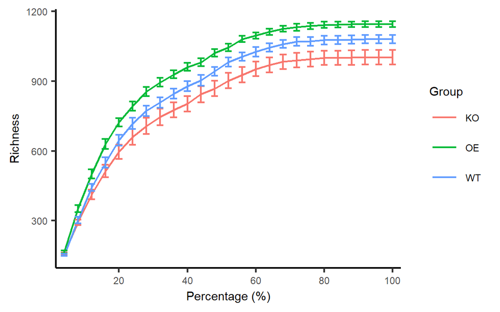

```r
# 绘制稀释曲线+标准误 Plotting alpha rarefaction curve in group mean with standard error
(p = alpha_rare_curve(alpha_rare, metadata, groupID = group))
```

```r
# 保存图片 Saving figure
ggsave("alpha/alpha_rarefaction_curve.pdf", p, width = width, height = height, units = "mm")
p2 = p
```

## 各组多样性种组比较 Venn/Upset/Sanky

命令行 sp_vennDiagram.sh 绘制维恩图

推荐使用`otu_group_exist.txt`在线 http://www.ehbio.com/ImageGP 绘制Venn/Upset/Sanky

# β多样性 Beta diversity

## 主坐标轴分析 PCoA

principal coordinate analysis (PCoA)

```r
# 主坐标轴分析，可选距离矩阵bray_curtis、unifrac、unifrac_binary、jaccard、manhatten、euclidean
# 设置距离矩阵类似，常用bray_curtis或unifrac
distance_type = "bray_curtis"
# Data reading
distance_mat = read.table(paste0("beta/",distance_type,".txt"), header=T, row.names=1, sep="\t", comment.char="")
distance_mat[1:3, 1:3]
```

|  | KO1 | KO2 | KO3 |
| --- | --- | --- | --- |
| KO1 | 0.000 | 0.298 | 0.337 |
| KO2 | 0.298 | 0.000 | 0.361 |
| KO3 | 0.337 | 0.361 | 0.000 |

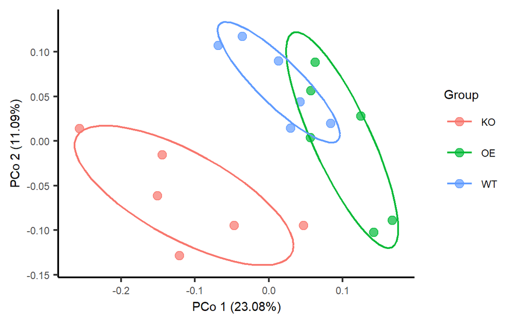

```r
# Plotting Constrained PCoA based on distance matrix
(p = beta_pcoa(distance_mat, metadata, groupID = group))
```

```r
# Saving figure
ggsave(paste0("beta/",distance_type,".pcoa.pdf"), p, width = width, height = height, units = "mm")
p3 = p

# statistic each pairwise by adonis
beta_pcoa_stat(distance_mat, metadata, groupID = group)
```

```
#>   sampA sampB
#> 1    KO    OE
#>   sampA sampB
#> 1    KO    WT
#>   sampA sampB
#> 1    OE    WT
```

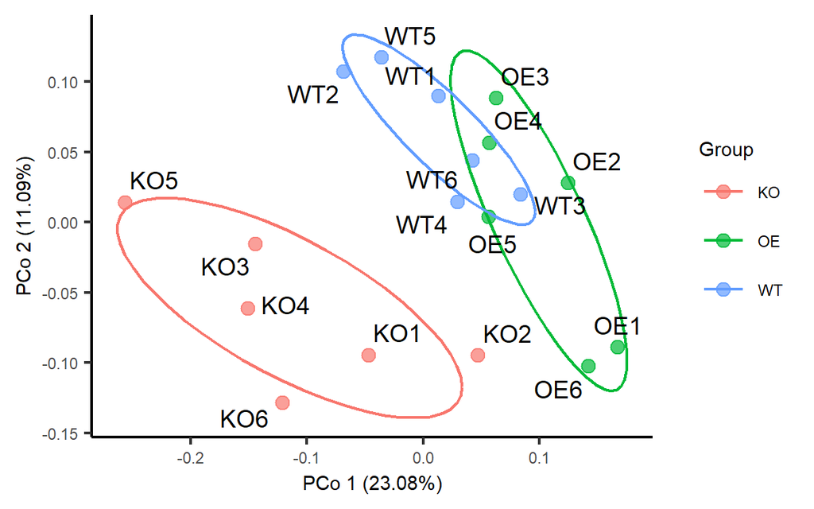

```r
# 结果文件默认见beta_pcoa_stat.txt

# 展示样本标签 Display sample label
(p = beta_pcoa(distance_mat, metadata, groupID = group, label = T))
```

```r
# 保存图片放大
ggsave(paste0("beta/",distance_type,".pcoa.label.pdf"), p, width = width*1.2, height = height*1.2, units = "mm")
```

## 有监督PCoA/CCA

Constrained PCoA

要求至少分组数量 >= 3时才可用，否则请跳过此步分析

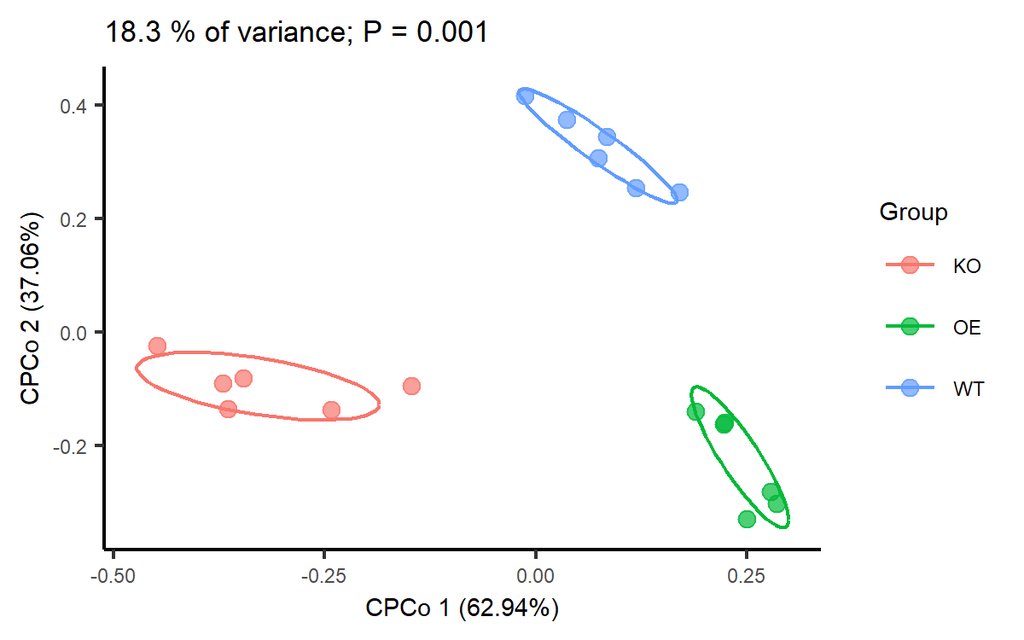

```r
# Plotting Constrained PCoA
(p = beta_cpcoa_dis(distance_mat, metadata, groupID = group))
```

```r
# Saving figure
ggsave(paste0("beta/",distance_type,".cpcoa.pdf"), p, width = width, height = height, units = "mm")
p4 = p
```

## 方差分解PERMANOVA

计算元数据中各变量是否对群落结构存在显著的影响

```r
# 预览元数据表头，确定要分析的变量
head(metadata,n=2)
```

|  | Group | Date | Site | CRA | CRR | BarcodeSequence | LinkerPrimerSequence | ReversePrimer | Batch | Species | Sequencing | Platform | latitude_longitude | Description |
| --- | --- | --- | --- | --- | --- | --- | --- | --- | --- | --- | --- | --- | --- | --- |
| KO1 | KO | 2017/6/30 | Chaoyang | CRA002352 | CRR117575 | ACGCTCGACA | AACMGGATTAGATACCCKG | ACGTCATCCCCACCTTCC | 1 | Arabidopsis thaliana | Novagene | HiSeq2500 | 39.59 N 116.22 E | Knock-out replicate 1 |
| KO2 | KO | 2017/6/30 | Chaoyang | CRA002352 | CRR117576 | ATCAGACACG | AACMGGATTAGATACCCKG | ACGTCATCCCCACCTTCC | 1 | Arabidopsis thaliana | Novagene | HiSeq2500 | 39.59 N 116.22 E | Knock-out replicate 2 |

```r
# 仅查看分组对群落的解释
adonis_var <- adonis (as.dist(distance_mat) ~ Group, data = metadata, by=NULL, parallel=4)
adonis_var$aov.tab
```

|  | Df | SumsOfSqs | MeanSqs | F.Model | R2 | Pr(>F) |
| --- | --- | --- | --- | --- | --- | --- |
| Group | 2 | 0.2351409 | 0.11757044 | 2.479793 | 0.2484814 | 0.001 |
| Residuals | 15 | 0.7111708 | 0.04741139 | NA | 0.7515186 | NA |
| Total | 17 | 0.9463117 | NA | NA | 1.0000000 | NA |

```r
write.table(adonis_var$aov.tab, file="beta/adonis_var_group.txt", append = F, sep="\t", quote=F, row.names=T, col.names=T)

# 计算Group, Date, Site三类变量及交互对群落结构差异的解释
adonis_var <- adonis (as.dist(distance_mat) ~ Group*Date*Site, data = metadata, by=NULL, parallel=4)
adonis_var$aov.tab
```

|  | Df | SumsOfSqs | MeanSqs | F.Model | R2 | Pr(>F) |
| --- | --- | --- | --- | --- | --- | --- |
| Group | 2 | 0.2351409 | 0.11757044 | 2.711502 | 0.2484814 | 0.001 |
| Date | 2 | 0.1023609 | 0.05118044 | 1.180364 | 0.1081683 | 0.165 |
| Group:Date | 4 | 0.2185709 | 0.05464274 | 1.260214 | 0.2309714 | 0.086 |
| Residuals | 9 | 0.3902390 | 0.04335989 | NA | 0.4123789 | NA |
| Total | 17 | 0.9463117 | NA | NA | 1.0000000 | NA |

```r
# 变量不能重合，否则无效。如本次Date与Site一致，所以Site无结果

# 计算Group和Site的解释率
adonis_var <- adonis (as.dist(distance_mat) ~ Group*Site, data = metadata, by=NULL, parallel=4)
adonis_var$aov.tab
```

|  | Df | SumsOfSqs | MeanSqs | F.Model | R2 | Pr(>F) |
| --- | --- | --- | --- | --- | --- | --- |
| Group | 2 | 0.2351409 | 0.11757044 | 2.711502 | 0.2484814 | 0.001 |
| Site | 2 | 0.1023609 | 0.05118044 | 1.180364 | 0.1081683 | 0.184 |
| Group:Site | 4 | 0.2185709 | 0.05464274 | 1.260214 | 0.2309714 | 0.100 |
| Residuals | 9 | 0.3902390 | 0.04335989 | NA | 0.4123789 | NA |
| Total | 17 | 0.9463117 | NA | NA | 1.0000000 | NA |

```r
write.table(adonis_var$aov.tab, file="beta/adonis_var.txt", append = F, sep="\t", quote=F, row.names=T, col.names=T)
```

# 物种组成 Taxonomy stackplot

## 堆叠柱状图 Stackplot

分别绘制样本和组均值的物种组成

Samples and groups

```r
# 设置分析级别 门p、纲c、目o、科f、属g
tax_level = "p"
# Data reading
tax_phylum = read.table(paste0("tax/sum_", tax_level, ".txt"), header=T, row.names=1, sep="\t", comment.char="")
tax_phylum[1:3, 1:3]
```

|  | KO1 | KO2 | KO3 |
| --- | --- | --- | --- |
| Proteobacteria | 68.10 | 54.10 | 62.80 |
| Actinobacteria | 24.30 | 37.10 | 26.50 |
| Firmicutes | 2.09 | 3.08 | 1.82 |

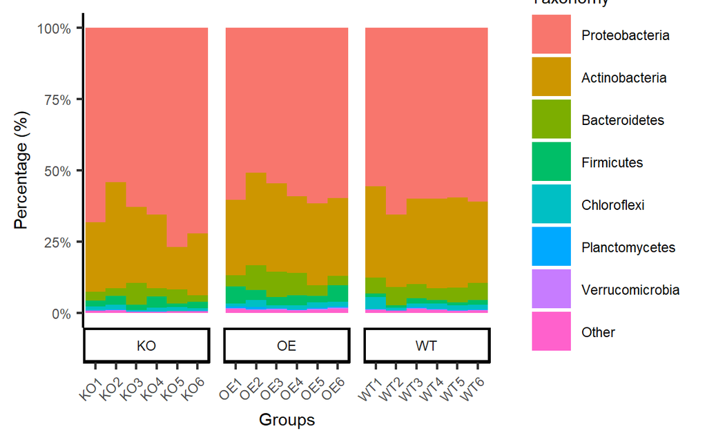

```r
# Plotting samples taxonomy composition
(p = tax_stackplot(tax_phylum, metadata, topN = 8, groupID = group, style = "sample", sorted = "abundance"))
```

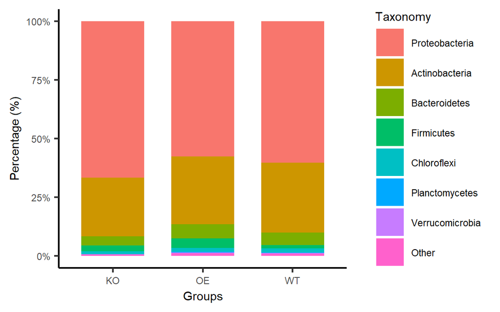

```r
p5 =p
ggsave(paste0("tax/", tax_level,"_sample.pdf"), p, width = width, height = height, units = "mm")

# Plotting groups taxonomy composition
(p = tax_stackplot(tax_phylum, metadata, topN = 8, groupID = group, style = "group", sorted = "abundance"))
```

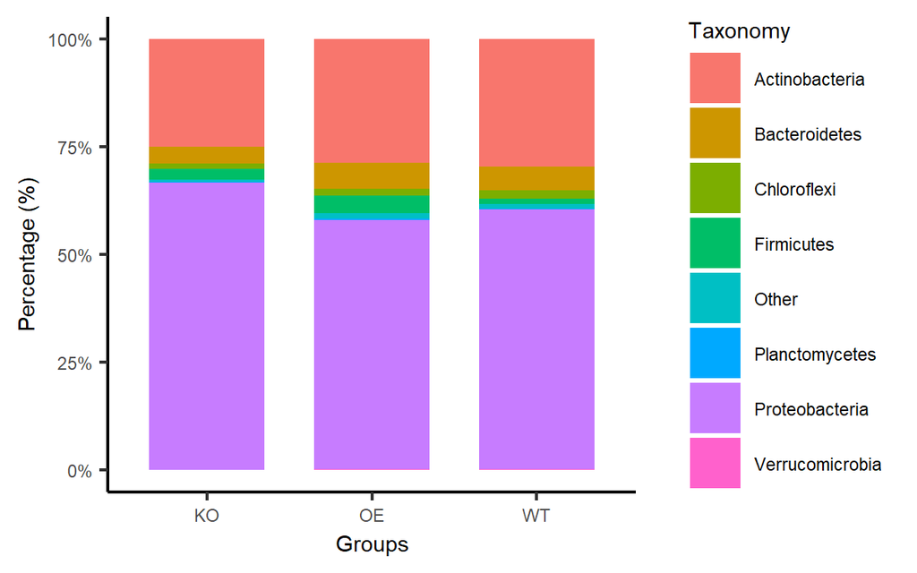

```r
p6 = p
ggsave(paste0("tax/", tax_level,"_group.pdf"), p, width = width, height = height, units = "mm")

# 按字母顺序排列
(p = tax_stackplot(tax_phylum, metadata, topN = 8, groupID = group, style = "group", sorted = "alphabet"))
```

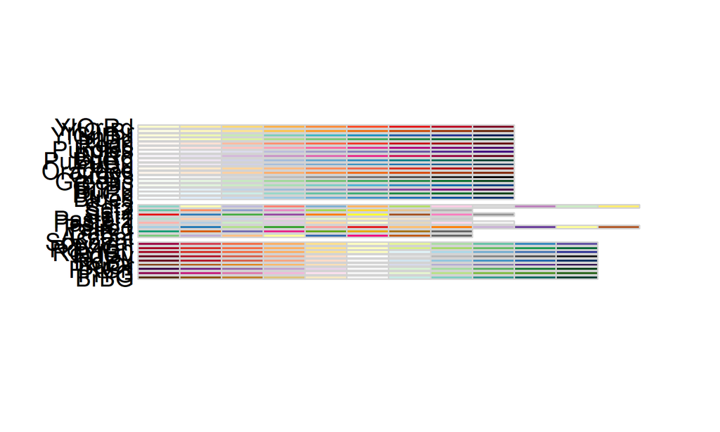

```r
# 修改配色方案
library(RColorBrewer)
display.brewer.all()
```

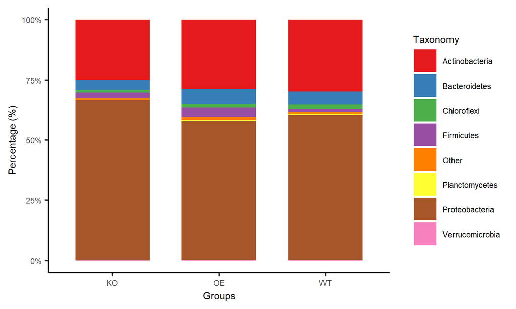

```r
(p = p + scale_fill_brewer(palette = "Set1"))
```

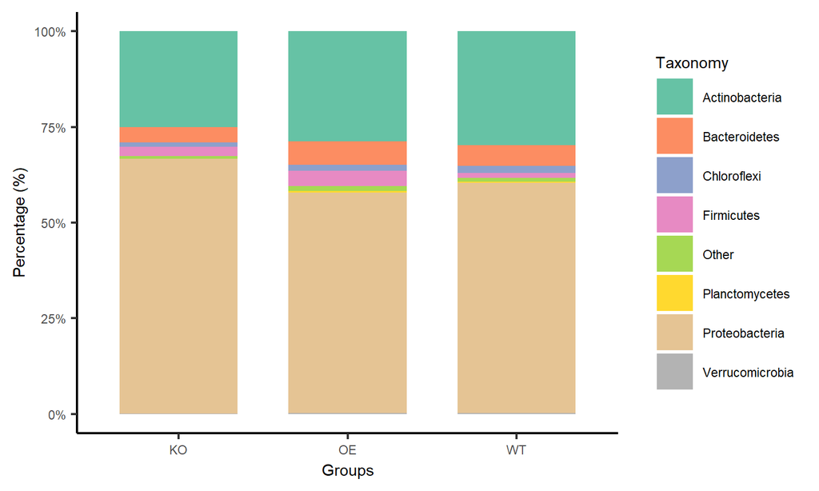

```r
ggsave(paste0("tax/", tax_level,"_group.Set1.pdf"), p, width = width, height = height, units = "mm")
(p = p + scale_fill_brewer(palette = "Set2"))
```

```r
ggsave(paste0("tax/", tax_level,"_group.Set2.pdf"), p, width = width, height = height, units = "mm")
```

## 弦图 circlize plot

```r
# 输出结果有当前目录下默认参数的弦图circlize.pdf，每次颜色随机
# 指定颜色和图例的弦图circlize_legend.pdf
tax_circlize(tax_phylum, metadata, topN = 5, groupID = group)
```

```r
# 查看结果不美观，尝试不同水平，如以纲为例
tax_class = read.table(paste0("tax/sum_c.txt"), header=T, row.names=1, sep="\t", comment.char="")
tax_circlize(tax_class, metadata, topN = 8, groupID = group)
```

# 排版 Combo plots

组合多个子图为发表格式

Combo plots to published-ready figure

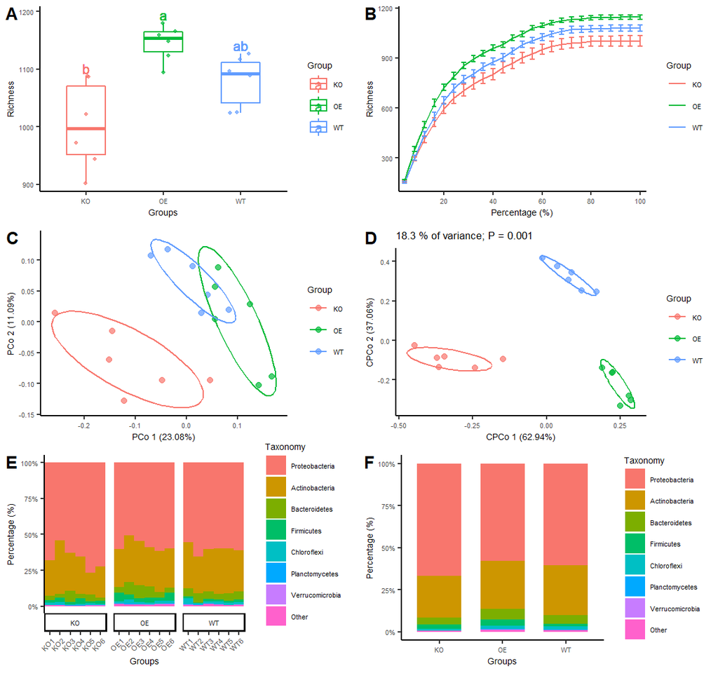

```r
library(cowplot)
(p0 = plot_grid(p1, p2, p3, p4, p5, p6, labels = c("A", "B", "C", "D", "E", "F"), ncol = 2))
```

```r
ggsave("diversity.pdf", p0, width = width * 2, height = height * 3, units = "mm")
```

使用此脚本，请引用下文：

If used this script, please cited:

**Yong-Xin Liu**, Yuan Qin, **Tong Chen**, et. al. A practical guide to amplicon and metagenomic analysis of microbiome data. **Protein Cell**, 2021(12) 5:315-330, doi: 10.1007/s13238-020-00724-8

Copyright 2016-2021 Yong-Xin Liu metagenome@126.com